# Final Project

Abbie Benfield, Annah Mutaya

5/5/2022

# Introduction

The dream of any emerging new artist is to produce a ‘charting’ song, one that is on repeat on the radio and making waves across the country. For our project, we decided to analyze the Spotify Top 200 Charts to see whether we could build a model that accurately predicts whether a song makes it into the top 20. The dataset we found consists of all 1556 songs found on the Spotify Top 200 Charts in 2020 and 2021, described by 23 different variables.

```r
library(tidyverse)
library(janitor)
library(skimr)
library(corrplot)
library(gbm)
library(e1071)
library(class)

spotify_full <- read_csv("spotify_dataset.csv") %>%
  clean_names() %>%
  mutate(top_20 = ifelse(highest_charting_position <= 20, TRUE, FALSE))

head(spotify_full)
```

```
## # A tibble: 6 × 24
##   index highest_charting_po… number_of_times… week_of_highest… song_name streams
##   <dbl>                <dbl>            <dbl> <chr>            <chr>       <dbl>
## 1     1                    1                8 2021-07-23--202… Beggin'    4.86e7
## 2     2                    2                3 2021-07-23--202… STAY (wi…  4.72e7
## 3     3                    1               11 2021-06-25--202… good 4 u   4.02e7
## 4     4                    3                5 2021-07-02--202… Bad Habi…  3.78e7
## 5     5                    5                1 2021-07-23--202… INDUSTRY…  3.39e7
## 6     6                    1               18 2021-05-07--202… MONTERO …  3.01e7
## # … with 18 more variables: artist <chr>, artist_followers <dbl>,
## #   song_id <chr>, genre <chr>, release_date <chr>, weeks_charted <chr>,
## #   popularity <dbl>, danceability <dbl>, energy <dbl>, loudness <dbl>,
## #   speechiness <dbl>, acousticness <dbl>, liveness <dbl>, tempo <dbl>,
## #   duration_ms <dbl>, valence <dbl>, chord <chr>, top_20 <lgl>
```

# Exploratory Data Analysis

```r
skim(spotify_full)
```

Data summary

| Name | spotify_full |
| --- | --- |
| Number of rows | 1556 |
| Number of columns | 24 |
| _______________________ |  |
| Column type frequency: |  |
| character | 8 |
| logical | 1 |
| numeric | 15 |
| ________________________ |  |
| Group variables | None |

**Variable type: character**

| skim_variable | n_missing | complete_rate | min | max | empty | n_unique | whitespace |
| --- | --- | --- | --- | --- | --- | --- | --- |
| week_of_highest_charting | 0 | 1.00 | 22 | 22 | 0 | 83 | 0 |
| song_name | 0 | 1.00 | 2 | 91 | 0 | 1556 | 0 |
| artist | 0 | 1.00 | 2 | 82 | 0 | 716 | 0 |
| song_id | 11 | 0.99 | 22 | 22 | 0 | 1516 | 0 |
| genre | 11 | 0.99 | 2 | 138 | 0 | 394 | 0 |
| release_date | 11 | 0.99 | 4 | 10 | 0 | 477 | 0 |
| weeks_charted | 0 | 1.00 | 22 | 3265 | 0 | 775 | 0 |
| chord | 11 | 0.99 | 1 | 5 | 0 | 12 | 0 |

**Variable type: logical**

| skim_variable | n_missing | complete_rate | mean | count |
| --- | --- | --- | --- | --- |
| top_20 | 0 | 1 | 0.15 | FAL: 1315, TRU: 241 |

**Variable type: numeric**

| skim_variable | n_missing | complete_rate | mean | sd | p0 | p25 | p50 | p75 | p100 | hist |
| --- | --- | --- | --- | --- | --- | --- | --- | --- | --- | --- |
| index | 0 | 1.00 | 778.50 | 449.32 | 1.00 | 389.75 | 778.50 | 1167.25 | 1556.00 | ▇▇▇▇▇ |
| highest_charting_position | 0 | 1.00 | 87.74 | 58.15 | 1.00 | 37.00 | 80.00 | 137.00 | 200.00 | ▇▇▆▅▅ |
| number_of_times_charted | 0 | 1.00 | 10.67 | 16.36 | 1.00 | 1.00 | 4.00 | 12.00 | 142.00 | ▇▁▁▁▁ |
| streams | 0 | 1.00 | 6340219.38 | 3369478.84 | 4176083.00 | 4915322.25 | 5275747.50 | 6455044.25 | 48633449.00 | ▇▁▁▁▁ |
| artist_followers | 11 | 0.99 | 14716902.87 | 16675788.51 | 4883.00 | 2123734.00 | 6852509.00 | 22698747.00 | 83337783.00 | ▇▂▂▁▁ |
| popularity | 11 | 0.99 | 70.09 | 15.82 | 0.00 | 65.00 | 73.00 | 80.00 | 100.00 | ▁▁▂▇▃ |
| danceability | 11 | 0.99 | 0.69 | 0.14 | 0.15 | 0.60 | 0.71 | 0.80 | 0.98 | ▁▂▅▇▃ |
| energy | 11 | 0.99 | 0.63 | 0.16 | 0.05 | 0.53 | 0.64 | 0.75 | 0.97 | ▁▂▆▇▃ |
| loudness | 11 | 0.99 | -6.35 | 2.51 | -25.17 | -7.49 | -5.99 | -4.71 | 1.51 | ▁▁▁▇▁ |
| speechiness | 11 | 0.99 | 0.12 | 0.11 | 0.02 | 0.05 | 0.08 | 0.16 | 0.88 | ▇▂▁▁▁ |
| acousticness | 11 | 0.99 | 0.25 | 0.25 | 0.00 | 0.05 | 0.16 | 0.39 | 0.99 | ▇▃▂▁▁ |
| liveness | 11 | 0.99 | 0.18 | 0.14 | 0.02 | 0.10 | 0.12 | 0.22 | 0.96 | ▇▂▁▁▁ |
| tempo | 11 | 0.99 | 122.81 | 29.59 | 46.72 | 97.96 | 122.01 | 143.86 | 205.27 | ▁▇▇▅▂ |
| duration_ms | 11 | 0.99 | 197940.82 | 47148.93 | 30133.00 | 169266.00 | 193591.00 | 218902.00 | 588139.00 | ▁▇▁▁▁ |
| valence | 11 | 0.99 | 0.51 | 0.23 | 0.03 | 0.34 | 0.51 | 0.69 | 0.98 | ▃▆▇▆▃ |

The first thing we noticed when looking at the skim output is that there are a small number of rows with missing values. Since there aren’t many of them, we dropped them when creating our cleaned data set. Something else that caught our eye is that there are fewer song IDs than rows, which means some songs repeat since each has a unique ID number. However, upon further observation, repeat IDs are separate versions of the song with different charting information, though the variables that describe the songs’ features are usually the same. Therefore, we decided to keep them because sometimes one version was a top 20 song while the other wasn’t. Also, looking at the small histograms created for the numerical variables, we noticed that some were a bit skewed while others were distributed more evenly. Thus, it reaffirmed our decision to scale the data for the procedures that are sensitive to scale.

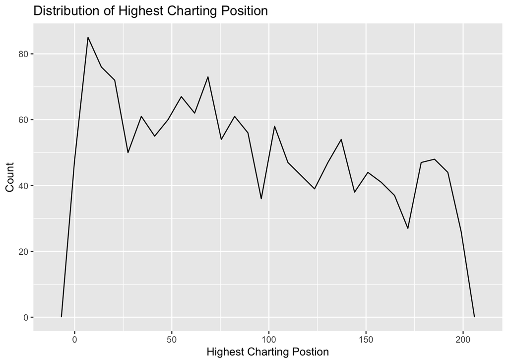

```r
ggplot(spotify_full, aes(x = highest_charting_position)) +
  geom_freqpoly(bins = 30) +
  labs(x = "Highest Charting Postion", y = "Count", title = "Distribution of Highest Charting Position")
```

For our primary variable, highest charting position (which is how we calculated top_20), we looked at a more detailed frequency plot to observe variation and saw that it was mostly evenly distributed.

```r
clean <- spotify_full %>%
  na.omit() %>%
  select(
    -index, -song_id, -weeks_charted, -week_of_highest_charting, -genre,
    -release_date, -chord, -song_name, -artist, -highest_charting_position
  )

skim(clean)
```

Data summary

| Name | clean |
| --- | --- |
| Number of rows | 1545 |
| Number of columns | 14 |
| _______________________ |  |
| Column type frequency: |  |
| logical | 1 |
| numeric | 13 |
| ________________________ |  |
| Group variables | None |

**Variable type: logical**

| skim_variable | n_missing | complete_rate | mean | count |
| --- | --- | --- | --- | --- |
| top_20 | 0 | 1 | 0.15 | FAL: 1307, TRU: 238 |

**Variable type: numeric**

| skim_variable | n_missing | complete_rate | mean | sd | p0 | p25 | p50 | p75 | p100 | hist |
| --- | --- | --- | --- | --- | --- | --- | --- | --- | --- | --- |
| number_of_times_charted | 0 | 1 | 10.68 | 16.39 | 1.00 | 1.00 | 4.00 | 12.00 | 142.00 | ▇▁▁▁▁ |
| streams | 0 | 1 | 6337136.38 | 3375402.18 | 4176083.00 | 4915080.00 | 5269163.00 | 6452492.00 | 48633449.00 | ▇▁▁▁▁ |
| artist_followers | 0 | 1 | 14716902.87 | 16675788.51 | 4883.00 | 2123734.00 | 6852509.00 | 22698747.00 | 83337783.00 | ▇▂▂▁▁ |
| popularity | 0 | 1 | 70.09 | 15.82 | 0.00 | 65.00 | 73.00 | 80.00 | 100.00 | ▁▁▂▇▃ |
| danceability | 0 | 1 | 0.69 | 0.14 | 0.15 | 0.60 | 0.71 | 0.80 | 0.98 | ▁▂▅▇▃ |
| energy | 0 | 1 | 0.63 | 0.16 | 0.05 | 0.53 | 0.64 | 0.75 | 0.97 | ▁▂▆▇▃ |
| loudness | 0 | 1 | -6.35 | 2.51 | -25.17 | -7.49 | -5.99 | -4.71 | 1.51 | ▁▁▁▇▁ |
| speechiness | 0 | 1 | 0.12 | 0.11 | 0.02 | 0.05 | 0.08 | 0.16 | 0.88 | ▇▂▁▁▁ |
| acousticness | 0 | 1 | 0.25 | 0.25 | 0.00 | 0.05 | 0.16 | 0.39 | 0.99 | ▇▃▂▁▁ |
| liveness | 0 | 1 | 0.18 | 0.14 | 0.02 | 0.10 | 0.12 | 0.22 | 0.96 | ▇▂▁▁▁ |
| tempo | 0 | 1 | 122.81 | 29.59 | 46.72 | 97.96 | 122.01 | 143.86 | 205.27 | ▁▇▇▅▂ |
| duration_ms | 0 | 1 | 197940.82 | 47148.93 | 30133.00 | 169266.00 | 193591.00 | 218902.00 | 588139.00 | ▁▇▁▁▁ |
| valence | 0 | 1 | 0.51 | 0.23 | 0.03 | 0.34 | 0.51 | 0.69 | 0.98 | ▃▆▇▆▃ |

To clean the data, we omitted the rows with missing values, the highest charting position variable because top_20 is derived from it, and the variables that contain characters because, while some of them may have interesting information, it is beyond the scope of this project to try and incorporate them as there are too many unique values to make them factors.

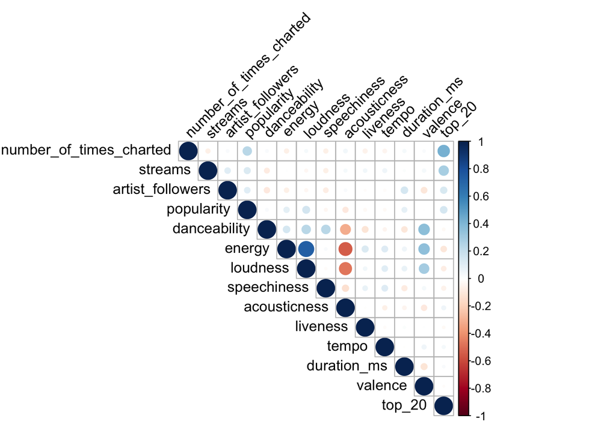

```r
corrplot(cor(clean), method = "circle", tl.col = "black", tl.srt = 45, type = "upper")
```

# Methodology

We first tried to utilize best subset selection, but we could not to run the code to completion.

```r
set.seed(1)

test <- clean %>%
  sample_n(1000)

train <- clean %>%
  setdiff(test)

scaled_test <- test %>%
  select(-top_20) %>%
  scale() %>%
  data.frame()

test_20 <- test %>%
  select(top_20) %>%
  .$top_20

scaled_train <- train %>%
  select(-top_20) %>%
  scale() %>%
  data.frame()

train_20 <- train %>%
  select(top_20) %>%
  .$top_20
```

We then tried different models to try and find the one best accuracy, starting with logistic regression.

## Logistic Regression

```r
glm_fit <- glm(top_20 ~ .,
  data = train,
  family = binomial
)

glm_probs <- data.frame(probs = predict(glm_fit,
  newdata = test,
  type = "response"
))

glm_pred <- glm_probs %>%
  mutate(pred = ifelse(probs > .5, TRUE, FALSE))

glm_pred <- cbind(test, glm_pred)

glm_pred %>%
  count(pred, top_20) %>%
  spread(top_20, n, fill = 0)
```

```
##    pred FALSE TRUE
## 1 FALSE   820  118
## 2  TRUE    17   45
```

```r
glm_pred %>%
  summarize(
    score = mean(pred == top_20),
    recip = mean(pred != top_20)
  )
```

```
##   score recip
## 1 0.865 0.135
```

```r
45 / (45 + 118)
```

```
## [1] 0.2760736
```

After fitting the logistic regression model, we notice that the model does pretty well in predicting whether a song is in the top 20, incorrectly categorizing only 13.5% of the time. However, it’s worth mentioning that the model performs better when classifying songs that didn’t make it into the top 20 compared to those that did. The former has a test accuracy of 98%, while the latter has a poor test accuracy of only 28%. Hence this is not the best model for predicting whether a song will make it into the top 20.

## KNN

We next tried KNN.

```r
val <- 0
kmax <- 1

for (k in 1:20) {
  set.seed(1)
  knn_pred <- knn(scaled_train, scaled_test, train_20, k)
  tab <- table(knn_pred, test_20)
  if ((tab[2, 2] / (tab[2, 2] + tab[1, 2])) > val) {
    val <- (tab[2, 2] / (tab[2, 2] + tab[1, 2]))
    kmax <- k
  }
}

val
```

```
## [1] 0.3496933
```

```r
kmax
```

```
## [1] 1
```

```r
knn_preds <- knn(scaled_train, scaled_test, train_20, kmax)
mean(knn_preds != test_20)
```

```
## [1] 0.163
```

```r
table(knn_preds, test_20)
```

```
##          test_20
## knn_preds FALSE TRUE
##     FALSE   780  106
##     TRUE     57   57
```

## Trees

We also tried a tree model with boosting.

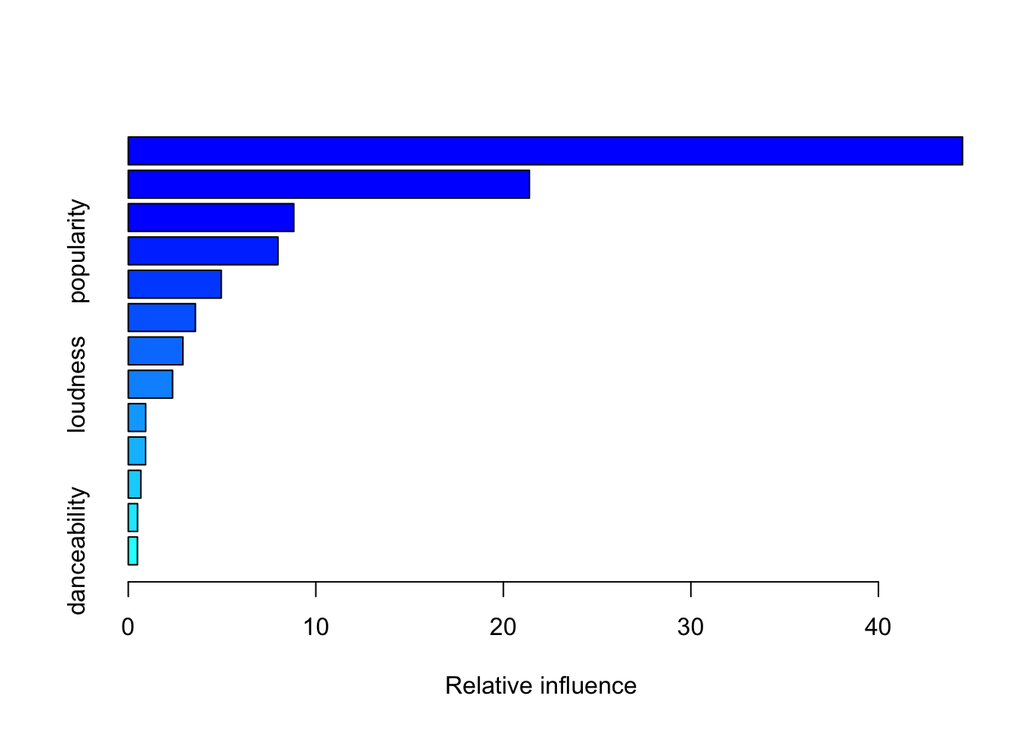

```
##                                             var    rel.inf
## number_of_times_charted number_of_times_charted 44.4873000
## streams                                 streams 21.3913442
## artist_followers               artist_followers  8.8258834
## popularity                           popularity  7.9819573
## acousticness                       acousticness  4.9572435
## energy                                   energy  3.5788757
## speechiness                         speechiness  2.9119778
## loudness                               loudness  2.3620319
## duration_ms                         duration_ms  0.9284431
## valence                                 valence  0.9226130
## tempo                                     tempo  0.6685564
## liveness                               liveness  0.4944183
## danceability                       danceability  0.4893554
```

```r
# Boosting
set.seed(1)
boost_fit <- gbm(top_20 ~ ., data = train, distribution = "bernoulli", n.trees = 1000, shrinkage = .01)

summary(boost_fit)
```

```r
boost_probs <- predict(boost_fit, newdata = test, n.trees = 1000, type = "response")
boost_preds <- ifelse(boost_probs > .2, TRUE, FALSE)
table(test$top_20, boost_preds)
```

```
##        boost_preds
##         FALSE TRUE
##   FALSE   739   98
##   TRUE     47  116
```

```r
mean(boost_preds != test$top_20)
```

```
## [1] 0.145
```

```r
116 / (98 + 116)
```

```
## [1] 0.5420561
```

## SVM

The last model we tried was SVM.

```r
set.seed(1)

clean <- clean %>%
  mutate(top_20 = as.factor(top_20))

test <- clean %>%
  sample_n(1000)

train <- clean %>%
  setdiff(test)

svm_fit <- tune(svm, top_20 ~ ., data = train, kernel = "linear", scale = TRUE, ranges = list(cost = c(0.01, 0.1, 1, 5, 10, 100)))

summary(svm_fit)
```

```
##
## Parameter tuning of 'svm':
##
## - sampling method: 10-fold cross validation
##
## - best parameters:
##  cost
##     1
##
## - best performance: 0.1118519
##
## - Detailed performance results:
##    cost     error dispersion
## 1 1e-02 0.1264646 0.04780966
## 2 1e-01 0.1136700 0.03801723
## 3 1e+00 0.1118519 0.03468460
## 4 5e+00 0.1118519 0.03468460
## 5 1e+01 0.1118519 0.03468460
## 6 1e+02 0.1118519 0.03468460
```

```r
bestmod <- svm_fit$best.model
summary(bestmod)
```

```
##
## Call:
## best.tune(method = svm, train.x = top_20 ~ ., data = train, ranges = list(cost = c(0.01,
##     0.1, 1, 5, 10, 100)), kernel = "linear", scale = TRUE)
##
##
## Parameters:
##    SVM-Type:  C-classification
##  SVM-Kernel:  linear
##        cost:  1
##
## Number of Support Vectors:  138
##
##  ( 68 70 )
##
##
## Number of Classes:  2
##
## Levels:
##  FALSE TRUE
```

```r
svm_pred <- predict(bestmod, test)
table(predicted = svm_pred, true = test$top_20)
```

```
##          true
## predicted FALSE TRUE
##     FALSE   823  124
##     TRUE     14   39
```

```r
(14 + 124) / 1000 # Overall error rate
```

```
## [1] 0.138
```

```r
39 / (39 + 124) # Accuracy rate for top 20 classification
```

```
## [1] 0.2392638
```

Though none of the models did exceptionally well, we choose the tree boosting model as our final model because it had the highest classification accuracy for top 20 songs, even though it had a higher overall error rate than logistic and SVM (see table below).

Model Comparison

[output not shown]

# Conclusion

Our final step was to apply our chosen tree boosting model to the complete dataset, first converting the top 20 variable back to a logical type.

```r
clean <- clean %>%
  mutate(top_20 = as.logical(top_20))

final_probs <- predict(boost_fit, newdata = clean, n.trees = 1000, type = "response")
final_preds <- ifelse(final_probs > .2, TRUE, FALSE)
table(clean$top_20, final_preds)
```

```
##        final_preds
##         FALSE TRUE
##   FALSE  1166  141
##   TRUE     60  178
```

```r
mean(final_preds != clean$top_20)
```

```
## [1] 0.1300971
```

```r
178 / (141 + 178)
```

```
## [1] 0.5579937
```

Our main takeaway from this project is that there is a likely a better model that could be created for this dataset, given the low accuracy rate for predicting top 20 songs. Future analysis could utilize better feature selection techniques and expand the types of models explored.

# References

- [Dataset](https://www.kaggle.com/datasets/sashankpillai/spotify-top-200-charts-20202021)
- [EDA Inspriation](https://www.kaggle.com/code/ippudkiippude/spotify-dataset-eda-prediction-classification)
- Correlation Plots